# Random forest in R

# Create Random forst algorithm using Bankruptcy data

Setup workspace

```r
rm(list=ls(all=TRUE))
setwd("C:\\Users\\samanoh\\training\\besantr\\random-forest-lab")
```

Read data

```r
# Read train and test data
train_data=read.csv(file = "Bankruptcy_data.csv",header = T)
#Check summary and convert to appropraite data types
str(train_data)
```

```
'data.frame':   36553 obs. of  66 variables:
 $ ID    : int  1 2 3 4 5 6 7 8 9 10 ...
 $ Attr1 : num  0.13537 0.00586 0.1106 0.06391 0.13168 ...
 $ Attr2 : num  0.452 0.399 0.161 1.407 0.66 ...
 $ Attr3 : num  0.312 0.198 0.479 -0.296 0.441 ...
 $ Attr4 : num  2.047 1.939 7.571 0.529 2.71 ...
 $ Attr5 : num  10.23 9.58 263.9 -46.29 -23.6 ...
 $ Attr6 : num  0.168 0 0 -0.714 -0.2 ...
 $ Attr7 : num  0.16763 0.00724 0.13836 0.07907 0.13191 ...
 $ Attr8 : num  1.213 1.509 5.205 -0.331 0.514 ...
 $ Attr9 : num  2.255 0.979 0.684 0.985 2.136 ...
 $ Attr10: num  0.548 0.601 0.839 -0.465 0.34 ...
 $ Attr11: num  0.1833 0.0295 0.1388 0.0791 0.1861 ...
 $ Attr12: num  0.5632 0.0344 1.8983 0.1258 0.5112 ...
 $ Attr13: num  0.0892 0.0364 0.2362 0.0303 0.1671 ...
```

[output cut: 52 more lines]

Drop the variable ID as it does not give any information

```r
#summary(train_data)
train_data$ID=NULL
```

Change structure of target variable

```r
train_data$target=as.factor(as.character(train_data$target))
str(train_data)
```

```
'data.frame':   36553 obs. of  65 variables:
 $ Attr1 : num  0.13537 0.00586 0.1106 0.06391 0.13168 ...
 $ Attr2 : num  0.452 0.399 0.161 1.407 0.66 ...
 $ Attr3 : num  0.312 0.198 0.479 -0.296 0.441 ...
 $ Attr4 : num  2.047 1.939 7.571 0.529 2.71 ...
 $ Attr5 : num  10.23 9.58 263.9 -46.29 -23.6 ...
 $ Attr6 : num  0.168 0 0 -0.714 -0.2 ...
 $ Attr7 : num  0.16763 0.00724 0.13836 0.07907 0.13191 ...
 $ Attr8 : num  1.213 1.509 5.205 -0.331 0.514 ...
 $ Attr9 : num  2.255 0.979 0.684 0.985 2.136 ...
 $ Attr10: num  0.548 0.601 0.839 -0.465 0.34 ...
 $ Attr11: num  0.1833 0.0295 0.1388 0.0791 0.1861 ...
 $ Attr12: num  0.5632 0.0344 1.8983 0.1258 0.5112 ...
 $ Attr13: num  0.0892 0.0364 0.2362 0.0303 0.1671 ...
 $ Attr14: num  0.16763 0.00724 0.13836 0.07907 0.13191 ...
```

[output cut: 51 more lines]

Check for NA values

```r
sum(is.na(train_data))
```

```
[1] 35187
```

```r
#install.packages("DMwR")
library(DMwR)
```

```r
# KNN imputation for train data : done separately for each class
#Split data based on target variable
train_data_0=train_data[train_data$target==0,]
train_data_1=train_data[train_data$target==1,]
train_data_0_knn=centralImputation(data = train_data_0)
sum(is.na(train_data_0_knn))
```

```
[1] 0
```

```r
train_data_1_knn=centralImputation(data = train_data_1)
sum(is.na(train_data_1_knn))
```

```
[1] 0
```

```r
# combine imputed data
train_data_knn=rbind(train_data_0_knn,train_data_1_knn)
```

Split the train data into train and validation sets

```r
#install.packages("ddalpha")
#install.packages("caret")
#install.packages("randomForest")
library(caret)
library(randomForest)
```

Split data

```r
rows=createDataPartition(y = train_data_knn$target,p=0.8,list=FALSE)
train_split=train_data_knn[rows,]
val_split=train_data_knn[-rows,]
```

Build Random forest

```r
model = randomForest(target ~ ., data=train_split,
                     keep.forest=TRUE,do.trace = TRUE, ntree=50)
```

```
ntree      OOB      1      2
    1:   5.59%  3.03% 54.60%
    2:   4.71%  2.66% 44.18%
    3:   4.63%  2.52% 45.20%
    4:   4.30%  2.33% 42.63%
    5:   4.01%  2.01% 43.51%
    6:   3.91%  1.89% 43.89%
    7:   3.66%  1.66% 42.97%
    8:   3.55%  1.49% 44.15%
    9:   3.26%  1.35% 40.98%
   10:   3.21%  1.22% 42.43%
   11:   3.14%  1.07% 43.80%
   12:   2.90%  0.81% 44.07%
   13:   2.81%  0.76% 43.08%
   14:   2.75%  0.64% 44.44%
```

[output cut: 36 more lines]

```r
table(train_split$target)
```

```
    0     1
27831  1412
```

```r
print(model)
```

```
Call:
 randomForest(formula = target ~ ., data = train_split, keep.forest = TRUE,      do.trace = TRUE, ntree = 50)
               Type of random forest: classification
                     Number of trees: 50
No. of variables tried at each split: 8

        OOB estimate of  error rate: 2.23%
Confusion matrix:
      0   1 class.error
0 27789  42 0.001509109
1   610 802 0.432011331
```

Predict on train data

```r
pred_Train = predict(model,train_split[,-65],type="response",norm.votes=TRUE)
```

Build confusion matrix on trained data

```r
#install.packages("e1071")
library(e1071)
```

```r
# Build confusion matrix and find accuracy
cm_Train = table("actual" = train_split$target, "predicted" = pred_Train)
confusionMatrix(data = pred_Train,reference = train_split$target,positive = "1")
```

```
Confusion Matrix and Statistics

          Reference
Prediction     0     1
         0 27831     0
         1     0  1412

               Accuracy : 1
                 95% CI : (0.9999, 1)
    No Information Rate : 0.9517
    P-Value [Acc > NIR] : < 2.2e-16

                  Kappa : 1
 Mcnemar's Test P-Value : NA

            Sensitivity : 1.00000
            Specificity : 1.00000
         Pos Pred Value : 1.00000
         Neg Pred Value : 1.00000
             Prevalence : 0.04829
         Detection Rate : 0.04829
   Detection Prevalence : 0.04829
      Balanced Accuracy : 1.00000

       'Positive' Class : 1
```

```r
sensitivity_Train <- cm_Train[2, 2]/sum(cm_Train[2, ])
specificity_Train <- cm_Train[1, 1]/sum(cm_Train[1, ])
accruacy_Train = sum(diag(cm_Train))/sum(cm_Train)
precision_Train= cm_Train[2, 2]/sum(cm_Train[,2])
F1_Train=2*precision_Train*sensitivity_Train/(precision_Train+sensitivity_Train)
```

Prediction on validation data

```r
pred_Val = predict(model, val_split[-65],type="response",norm.votes=TRUE)
```

Build confusion matrix on validation data

```r
cm_Val = table("actual" = val_split$target, "predicted" = pred_Val);
confusionMatrix(data = pred_Val,reference = val_split$target,positive = "1")
```

```
Confusion Matrix and Statistics

          Reference
Prediction    0    1
         0 6947  150
         1   10  203

               Accuracy : 0.9781
                 95% CI : (0.9745, 0.9813)
    No Information Rate : 0.9517
    P-Value [Acc > NIR] : < 2.2e-16

                  Kappa : 0.7067
 Mcnemar's Test P-Value : < 2.2e-16

            Sensitivity : 0.57507
            Specificity : 0.99856
         Pos Pred Value : 0.95305
         Neg Pred Value : 0.97886
             Prevalence : 0.04829
         Detection Rate : 0.02777
   Detection Prevalence : 0.02914
      Balanced Accuracy : 0.78682

       'Positive' Class : 1
```

```r
sensitivity_Val <- cm_Val[2, 2]/sum(cm_Val[2, ])
specificity_Val <- cm_Val[1, 1]/sum(cm_Val[1, ])
accruacy_Val = sum(diag(cm_Val))/sum(cm_Val)
precision_Val= cm_Val[2, 2]/sum(cm_Val[,2])
F1_Val=2*precision_Val*sensitivity_Val/(precision_Val+sensitivity_Val)
```

Get important attributes from the model

```r
# Important attributes
model$importance
```

```
       MeanDecreaseGini
Attr1          24.76749
Attr2          25.74471
Attr3          23.71532
Attr4          22.02474
Attr5          28.26539
Attr6          27.02352
Attr7          25.91302
Attr8          25.63800
Attr9          31.84757
Attr10         28.60338
Attr11         21.57241
Attr12         22.05171
Attr13         23.39527
Attr14         24.81666
Attr15         27.57808
Attr16         34.26733
Attr17         32.13267
Attr18         20.28391
Attr19         19.30325
Attr20         29.37765
Attr21        123.25717
Attr22         26.21225
Attr23         22.27928
Attr24         53.77374
Attr25         26.58513
Attr26         34.85275
Attr27        214.67091
Attr28         28.01338
Attr29         35.42358
Attr30         34.22919
Attr31         24.56758
Attr32         22.85665
Attr33         20.59259
Attr34         79.45402
Attr35         32.78419
Attr36         23.28693
Attr37        380.07729
Attr38         39.84917
Attr39         39.93654
```

[output cut: 10 more lines]

```
Attr50         42.86029
Attr51         28.86427
Attr52         17.83749
Attr53         39.88439
Attr54         28.19515
Attr55         31.04734
Attr56         46.16728
Attr57         22.38773
Attr58         48.97824
Attr59        139.77422
Attr60         29.23914
Attr61         31.57626
Attr62         17.98633
Attr63         19.43046
Attr64         30.72605
```

```r
round(importance(model), 2)
```

```
       MeanDecreaseGini
Attr1             24.77
Attr2             25.74
Attr3             23.72
Attr4             22.02
Attr5             28.27
Attr6             27.02
Attr7             25.91
Attr8             25.64
Attr9             31.85
Attr10            28.60
Attr11            21.57
Attr12            22.05
Attr13            23.40
Attr14            24.82
Attr15            27.58
Attr16            34.27
Attr17            32.13
Attr18            20.28
Attr19            19.30
Attr20            29.38
Attr21           123.26
Attr22            26.21
Attr23            22.28
Attr24            53.77
Attr25            26.59
Attr26            34.85
Attr27           214.67
Attr28            28.01
Attr29            35.42
Attr30            34.23
Attr31            24.57
Attr32            22.86
Attr33            20.59
Attr34            79.45
Attr35            32.78
Attr36            23.29
Attr37           380.08
Attr38            39.85
Attr39            39.94
```

[output cut: 10 more lines]

```
Attr50            42.86
Attr51            28.86
Attr52            17.84
Attr53            39.88
Attr54            28.20
Attr55            31.05
Attr56            46.17
Attr57            22.39
Attr58            48.98
Attr59           139.77
Attr60            29.24
Attr61            31.58
Attr62            17.99
Attr63            19.43
Attr64            30.73
```

Extract important attributes for further iteration

```r
rf_Imp_Attr = data.frame(model$importance)
rf_Imp_Attr = data.frame(row.names(rf_Imp_Attr),rf_Imp_Attr[,1])
colnames(rf_Imp_Attr) = c('Attributes', 'Importance')
rf_Imp_Attr = rf_Imp_Attr[order(rf_Imp_Attr$Importance, decreasing = TRUE),]
```

Plot important variables

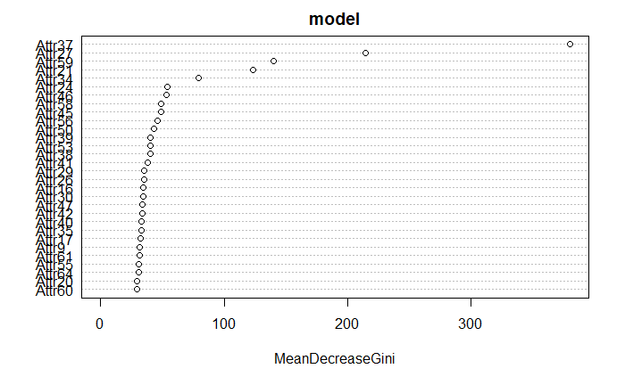

```r
# plot (directly prints the important attributes)
varImpPlot(model)
```

# Build random forest using top5 important attributes

```r
# Build randorm forest using top 5 important attributes.
top_Imp_Attr = as.character(rf_Imp_Attr$Attributes[1:5])
```

Build classification using random forest

```r
model_Imp = randomForest(target~.,
                         data=train_split[,c(top_Imp_Attr,"target")],
                         keep.forest=TRUE,ntree=50,do.trace = TRUE)
```

```
ntree      OOB      1      2
    1:   2.29%  1.16% 23.70%
    2:   2.33%  1.25% 23.25%
    3:   2.50%  1.44% 23.54%
    4:   2.36%  1.29% 23.90%
    5:   2.31%  1.19% 24.66%
    6:   2.11%  1.02% 23.67%
    7:   1.95%  0.90% 22.72%
    8:   1.77%  0.75% 22.09%
    9:   1.76%  0.69% 22.89%
   10:   1.66%  0.60% 22.56%
   11:   1.62%  0.55% 22.59%
   12:   1.56%  0.49% 22.62%
   13:   1.53%  0.45% 22.78%
   14:   1.49%  0.40% 22.84%
```

[output cut: 36 more lines]

Print and understand the model

```r
print(model_Imp)
```

```
Call:
 randomForest(formula = target ~ ., data = train_split[, c(top_Imp_Attr,      "target")], keep.forest = TRUE, ntree = 50, do.trace = TRUE)
               Type of random forest: classification
                     Number of trees: 50
No. of variables tried at each split: 2

        OOB estimate of  error rate: 1.24%
Confusion matrix:
      0    1 class.error
0 27773   58 0.002084007
1   304 1108 0.215297450
```

Importance attributes

```r
# Important attributes
model_Imp$importance
```

```
       MeanDecreaseGini
Attr37         820.3174
Attr27         551.7361
Attr59         452.2148
Attr21         600.3115
Attr34         242.7168
```

Predict on train data

```r
# Predict on Train data
pred_Train = predict(model_Imp,
                     train_split[,setdiff(names(train_split), "target")],
                     type="response",
                     norm.votes=TRUE)
```

Build confusion matrix and accuracy on train data

```r
cm_Train = table("actual" = train_split$target, "predicted" = pred_Train);
confusionMatrix(data = pred_Train,reference = train_split$target,positive = "1")
```

```
Confusion Matrix and Statistics

          Reference
Prediction     0     1
         0 27830    15
         1     1  1397

               Accuracy : 0.9995
                 95% CI : (0.9991, 0.9997)
    No Information Rate : 0.9517
    P-Value [Acc > NIR] : < 2.2e-16

                  Kappa : 0.994
 Mcnemar's Test P-Value : 0.001154

            Sensitivity : 0.98938
            Specificity : 0.99996
         Pos Pred Value : 0.99928
         Neg Pred Value : 0.99946
             Prevalence : 0.04829
         Detection Rate : 0.04777
   Detection Prevalence : 0.04781
      Balanced Accuracy : 0.99467

       'Positive' Class : 1
```

```r
sensitivity_Train <- cm_Train[2, 2]/sum(cm_Train[2, ])
specificity_Train <- cm_Train[1, 1]/sum(cm_Train[1, ])
accruacy_Train = sum(diag(cm_Train))/sum(cm_Train)
precision_Train= cm_Train[2, 2]/sum(cm_Train[,2])
F1_Train=2*precision_Train*sensitivity_Train/(precision_Train+sensitivity_Train)
```

Predict on validation data

```r
pred_Val = predict(model_Imp, val_split[,setdiff(names(val_split),
                                                 "target")],
                   type="response",
                   norm.votes=TRUE)
```

Build confusion matrix and accuracy on validation data

```r
cm_Val = table("actual" = val_split$target, "predicted" = pred_Val);
confusionMatrix(data = pred_Val,reference = val_split$target,positive = "1")
```

```
Confusion Matrix and Statistics

          Reference
Prediction    0    1
         0 6942   84
         1   15  269

               Accuracy : 0.9865
                 95% CI : (0.9835, 0.989)
    No Information Rate : 0.9517
    P-Value [Acc > NIR] : < 2.2e-16

                  Kappa : 0.8376
 Mcnemar's Test P-Value : 8.243e-12

            Sensitivity : 0.76204
            Specificity : 0.99784
         Pos Pred Value : 0.94718
         Neg Pred Value : 0.98804
             Prevalence : 0.04829
         Detection Rate : 0.03680
   Detection Prevalence : 0.03885
      Balanced Accuracy : 0.87994

       'Positive' Class : 1
```

```r
sensitivity_Val <- cm_Val[2, 2]/sum(cm_Val[2, ])
specificity_Val <- cm_Val[1, 1]/sum(cm_Val[1, ])
accruacy_Val = sum(diag(cm_Val))/sum(cm_Val)
precision_Val= cm_Val[2, 2]/sum(cm_Val[,2])
F1_Val=2*precision_Val*sensitivity_Val/(precision_Val+sensitivity_Val)
```

# Build C5.0 model

Install libraries

```r
#install.packages("C50")
library(C50)
```

Build model

```r
c5_model = C5.0(x = train_data_knn[,-65],y = train_data_knn[,65])
summary(c5_model)
```

```
Call:
C5.0.default(x = train_data_knn[, -65], y = train_data_knn[, 65])


C5.0 [Release 2.07 GPL Edition]     Fri Dec 14 08:01:01 2018
-------------------------------

Class specified by attribute `outcome'

Read 36553 cases (65 attributes) from undefined.data

Decision tree:

Attr37 <= 2.9271:
:...Attr37 > 2.6517:
:   :...Attr37 <= 2.6519: 1 (835)
:   :   Attr37 > 2.6519: 0 (513/31)
:   Attr37 <= 2.6517:
:   :...Attr41 <= 0.0015259:
:       :...Attr27 > -0.0305:
:       :   :...Attr27 > 0.97022: 0 (30)
:       :   :   Attr27 <= 0.97022:
:       :   :   :...Attr42 <= -5.1386e-005: 1 (50)
:       :   :       Attr42 > -5.1386e-005: 0 (3)
:       :   Attr27 <= -0.0305:
:       :   :...Attr56 <= 0.055466:
:       :       :...Attr34 <= 0.010152: 0 (329)
:       :       :   Attr34 > 0.010152:
:       :       :   :...Attr21 > 0.98839: 0 (276/8)
:       :       :       Attr21 <= 0.98839:
:       :       :       :...Attr21 <= 0.98138: 0 (317/30)
:       :       :           Attr21 > 0.98138: 1 (35)
:       :       Attr56 > 0.055466:
:       :       :...Attr35 > -0.0034142: 0 (28)
:       :           Attr35 <= -0.0034142:
:       :           :...Attr5 > 108.41: 0 (7)
:       :               Attr5 <= 108.41:
:       :               :...Attr34 > 0.18129: 1 (26)
:       :                   Attr34 <= 0.18129:
:       :                   :...Attr15 <= -5668.4: 1 (3)
```

[output cut: 146 more lines]

```
      1.76% Attr15
      1.58% Attr58
      0.67% Attr44
      0.39% Attr45
      0.26% Attr60
      0.19% Attr62
      0.17% Attr42
      0.11% Attr30
      0.08% Attr12
      0.05% Attr29
      0.04% Attr39
      0.03% Attr22


Time: 7.4 secs
```

Predict model on training data

```r
c5_pred = predict(c5_model,train_data_knn[,-65])
c5_cm = table(c5_pred,train_data_knn$target)
c5_cm
```

```
c5_pred     0     1
      0 34773   353
      1    15  1412
```

```r
library(MLmetrics)
```

```r
Recall(y_true = train_data_knn$target,y_pred = c5_pred)
```

```
[1] 0.9995688
```

```r
F1_Score(y_true = train_data_knn$target,y_pred = c5_pred)
```

```
[1] 0.9947364
```

Predict model on validation data

```r
c5_pred_val = predict(object = c5_model,val_split[,-65])
c5_val_cm = table(c5_pred_val,val_split$target)
```

Compute metrics on validation data

```r
Recall(y_true = val_split$target,y_pred = c5_pred_val)
```

```
[1] 0.999425
```

```r
F1_Score(y_true = val_split$target,y_pred = c5_pred_val)
```

```
[1] 0.9941378
```

# Build CART model

```r
#install.packages("rpart")
library(rpart)
```

Build CART model

```r
cart_model = rpart(train_data_knn$target~.,data = train_data_knn)
summary(cart_model)
```

```
Call:
rpart(formula = train_data_knn$target ~ ., data = train_data_knn)
  n= 36553

         CP nsplit rel error    xerror       xstd
1 0.2365439      0 1.0000000 1.0000000 0.02322100
2 0.0266289      2 0.5269122 0.5620397 0.01760097
3 0.0100000      5 0.4470255 0.4498584 0.01579053

Variable importance
Attr37 Attr50 Attr34 Attr27 Attr30 Attr17  Attr8 Attr59 Attr22 Attr42 Attr53 Attr41 Attr19 Attr24 Attr12
    49      8      8      8      7      3      3      3      2      2      1      1      1      1      1

Node number 1: 36553 observations,    complexity param=0.2365439
  predicted class=0  expected loss=0.04828605  P(node) =1
    class counts: 34788  1765
   probabilities: 0.952 0.048
  left son=2 (26242 obs) right son=3 (10311 obs)
  Primary splits:
      Attr37 < 2.652       to the right, improve=173.83480, (0 missing)
      Attr41 < -0.00063602 to the right, improve=101.18060, (0 missing)
      Attr35 < -0.0393365  to the right, improve= 99.46119, (0 missing)
      Attr39 < -0.034809   to the right, improve= 96.63891, (0 missing)
      Attr26 < 0.063208    to the right, improve= 92.83568, (0 missing)
  Surrogate splits:
      Attr59 < 0.247255    to the left,  agree=0.873, adj=0.550, (0 split)
      Attr50 < 0.76472     to the right, agree=0.804, adj=0.304, (0 split)
      Attr53 < 0.79448     to the right, agree=0.783, adj=0.229, (0 split)
      Attr30 < 0.44859     to the left,  agree=0.769, adj=0.180, (0 split)
      Attr64 < 1.73275     to the right, agree=0.735, adj=0.059, (0 split)

Node number 2: 26242 observations
  predicted class=0  expected loss=0.01771969  P(node) =0.7179165
    class counts: 25777   465
   probabilities: 0.982 0.018

Node number 3: 10311 observations,    complexity param=0.2365439
  predicted class=0  expected loss=0.1260789  P(node) =0.2820835
    class counts:  9011  1300
   probabilities: 0.874 0.126
```

[output cut: 77 more lines]

```
      Attr34 < 0.066069    to the right, agree=0.944, adj=0.560, (0 split)
      Attr42 < -0.00014982 to the right, agree=0.906, adj=0.255, (0 split)
      Attr22 < -0.00365795 to the right, agree=0.905, adj=0.248, (0 split)
      Attr41 < -0.061986   to the right, agree=0.896, adj=0.177, (0 split)
      Attr19 < -0.37664    to the right, agree=0.879, adj=0.043, (0 split)

Node number 54: 975 observations
  predicted class=0  expected loss=0.07282051  P(node) =0.0266736
    class counts:   904    71
   probabilities: 0.927 0.073

Node number 55: 141 observations
  predicted class=1  expected loss=0  P(node) =0.003857413
    class counts:     0   141
   probabilities: 0.000 1.000
```

```r
length(train_data_knn$target)
```

```
[1] 36553
```

Predict train data using CART

```r
cart_pred = predict(cart_model,train_data_knn[,-65], ,type = "class")
cart_cm = table(cart_pred,train_data_knn$target)
```

Metrics for train data in CART

```r
#library(MLmetrics)
Recall(y_true = train_data_knn$target,y_pred = cart_pred)
```

```
[1] 1
```

```r
F1_Score(y_true = train_data_knn$target,y_pred = cart_pred)
```

```
[1] 0.988787
```

Predict validation data using CART

```r
cart_pred_val = predict(object = cart_model ,val_split[,-65], type = "class")
cart_val_cm = table(cart_pred_val ,val_split$target)
```

Metrics for validation data in CART

```r
Recall(y_true = val_split$target,y_pred = cart_pred_val)
```

```
[1] 1
```

```r
F1_Score(y_true = val_split$target,y_pred = cart_pred_val)
```

```
[1] 0.9883506
```